# **Project 3 : Predict Default Risks**

Jiawen

## **Step 1:Business and Data Understanding**

### **Key Decisions**

#### 1.What decisions needs to be made?

- We need to build the classification model with high accuracy in identifying whether the new loan applicants are creditworthy or not.

#### 2.What data is needed to inform those decisions?

- Variables : Explore the possible variables which imply the applicant’s financial stability, risk affordability and thus help evaluating the creditworthiness
  - Applicant’s finance information, e.g. most valuable available asses, valuesaving stocks
  - Applicant’s demographic information, e.g. age, length of current employment, duration in current address, number of dependents, whether is foreign worker or not
  - Applicant’s credit-related information, e.g. duration of credit, payment status of previous credit, number of credits at this bank, credit amount
  - Applicant’s loan request information, e.g. purpose
- Training dataset: To build the model, we also need applicant’s credit application result within our training dataset
- Testing dataset : we need the dataset including the above variables, and apply the data model which is trained by the training dataset to predict the credit results for the applicants

#### 3.What kind of model (Continuous, Binary, Non-Binary, Time-Series) do we need to use to help make these decisions?

- We need to build Binary Classification Model to make the business decision

## **Step 2:Building the Training Set**

### **Key Guidelines**

#### **Attributes to evaluate while cleaning data**

#### Correlation

- For numerical data fields, are there any fields that highly-correlate with each other? *The correlation should be at least .70 to be considered “high”

#### Missing Data

- Are there any missing data for each of the data fields?
- Fields with a lot of missing data should be removed

#### Variability

- Are there only a few values in a subset of your data field?
- Does the data field look very uniform (there is only one value for the entire field?)
- This is called “low variability” and fields with low variability should be removed

### **Key Results**

#### **Actions taken while cleaning the data**

[output not shown]

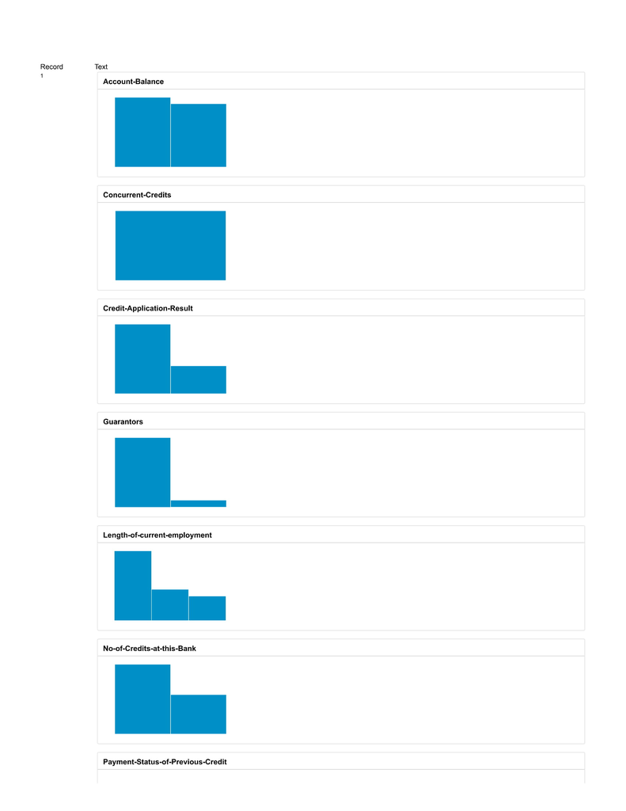

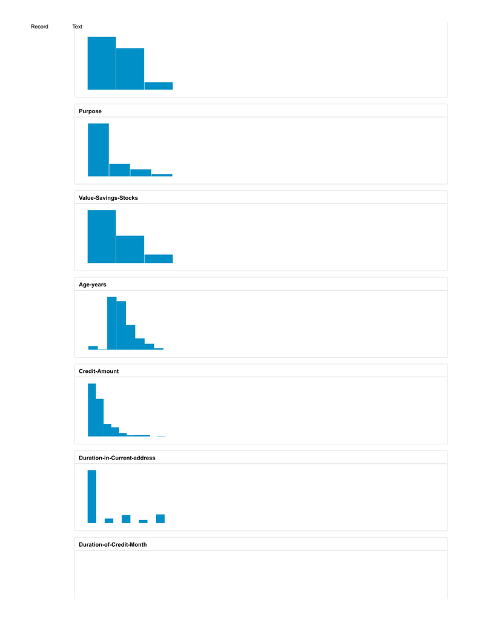

## **Step 3:Train your Classification Models**

#### **Understand model’s key predictors**

#### Model 1 : Logistic Regression Model

- Most Significant Predictors : Account Balance_Some Balnce, p-value=1.65e-07

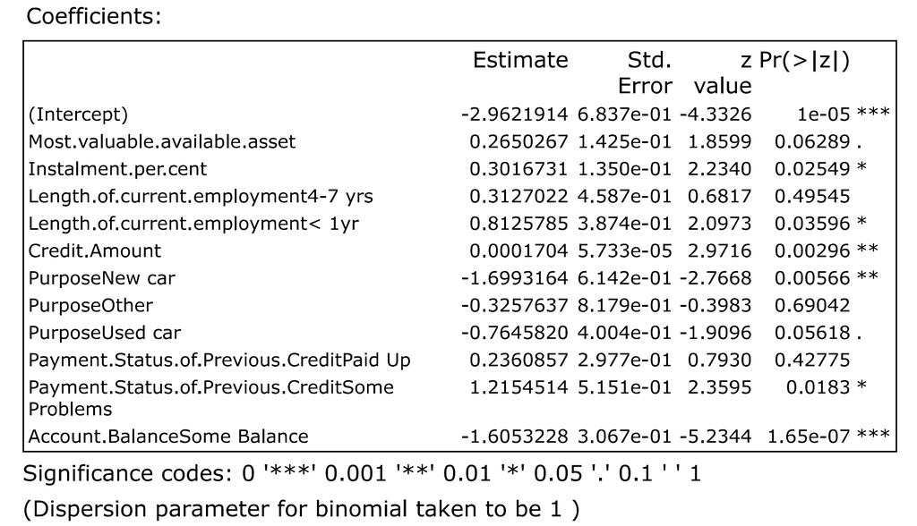

#### Model 2 : Decision Tree Model

- Most Significant Predictors : Account Balance

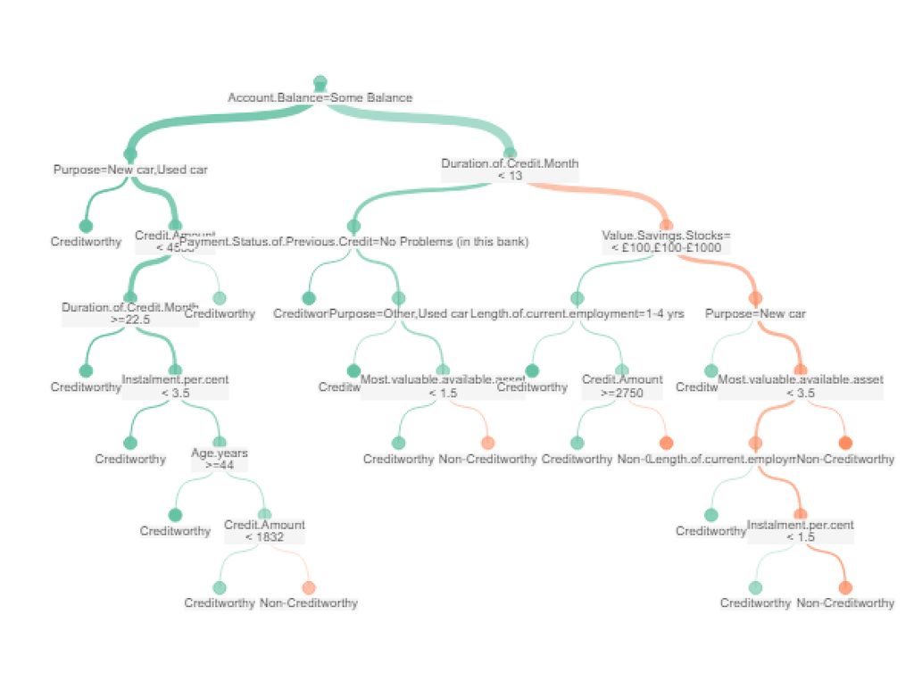

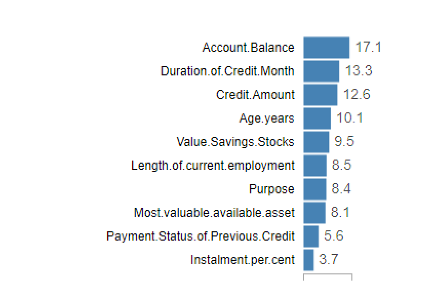

#### Model 3 : Random Forest Model

- Most Significant Predictors : Credit Amount

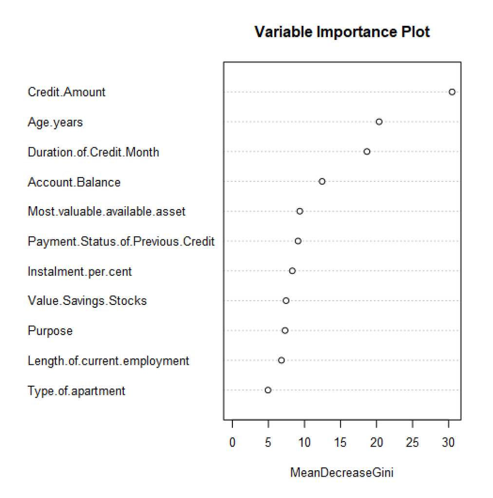

#### Model 4 : Boosted Model

- Most Significant Predictors :Account Balance

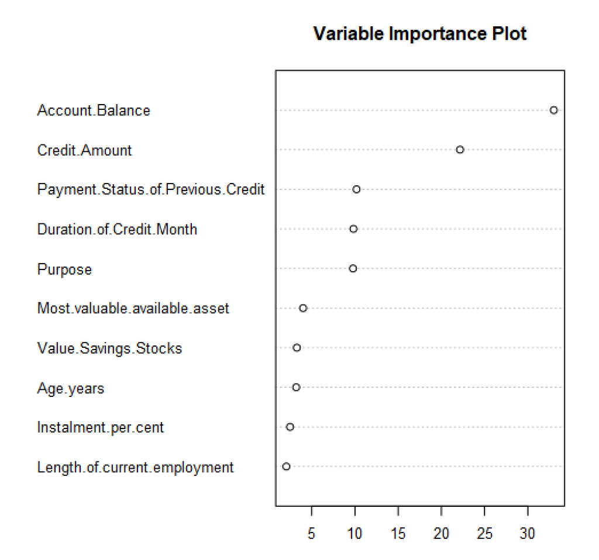

#### **Validate models against the validation set**

#### Model 1 : Logistic Regression Model

[figure not shown]

- Predictions Bias
  - There is bias seen in the model’s prediction to Creditworthy
    $$PPV= True Positives(TruePositives + FalsePositives)= 0.80$$
    $$NPV= TrueNegatives(TrueNegatives + FalseNegatives) =0.63$$

#### Model 2 : Decision Tree Model

- Overall Percent Accuracy=0.6867
- Confusion Matrix

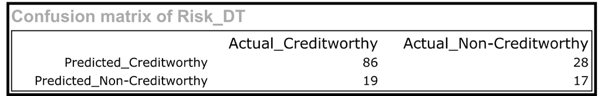

- Predictions Bias
  - There is bias seen in the model’s prediction to Creditworthy
    $$PPV= True Positives(TruePositives + FalsePositives)= 0.75$$
    $$NPV= TrueNegatives(TrueNegatives + FalseNegatives) =0.47$$

#### Model 3 : Random Forest Model

- Overall Percent Accuracy=0.8000
- Confusion Matrix

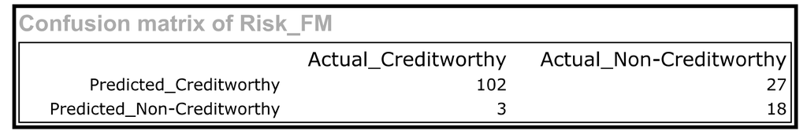

- Predictions Bias
  - There is no bias seen in the model
    $$PPV= True Positives(TruePositives + FalsePositives)= 0.79$$
    $$NPV= TrueNegatives(TrueNegatives + FalseNegatives) =0.86$$

#### Model 4 : Boosted Model

- Overall Percent Accuracy=0.7867
- Confusion Matrix

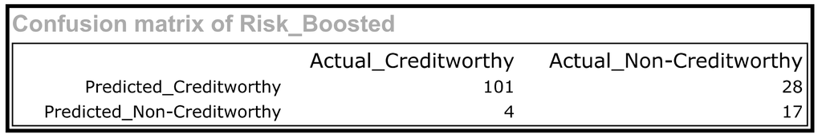

- Predictions Bias
  - There is no bias seen in the model
    $$PPV= True Positives(TruePositives + FalsePositives)= 0.78$$
    $$NPV= TrueNegatives(TrueNegatives + FalseNegatives) =0.81$$

## **Step 4:Recommendations**

### Model Comparison

#### Finally, I chose the Random Forest Model (Risk_FM) for the following reasons

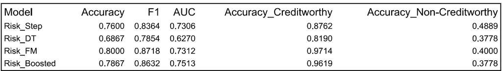

- ROC graph curve is steep
  - Random Forest Model ranksthe second in terms of the height of ROC curve
  - Note : The highest ROC indicates “for a given amount of false positive predictions (wrongly predicted creditworthy people), this model will give the best number of true positive predictions (correctly predicted creditworthy people)”

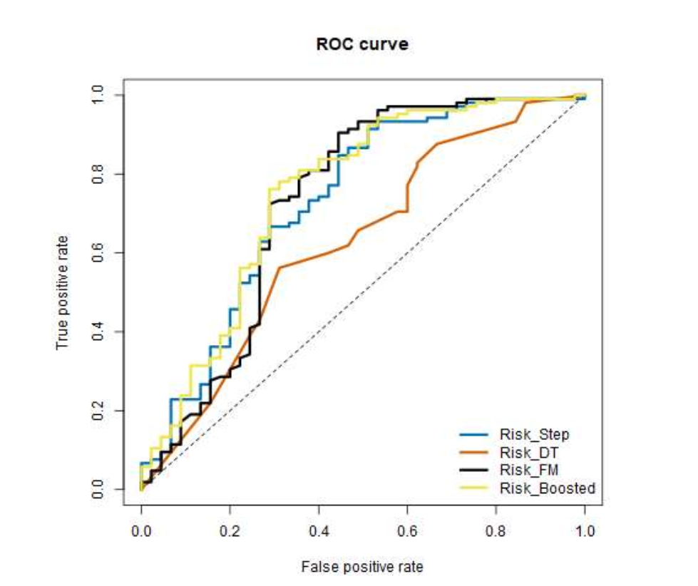

### **Appendix : Alteryx Workflow**

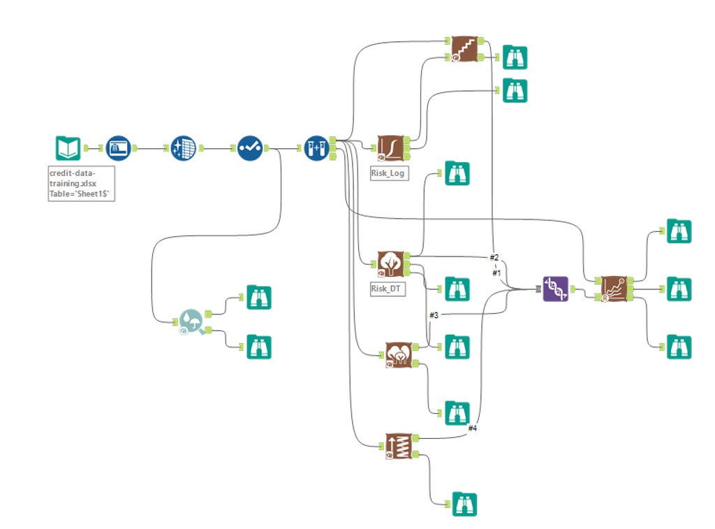